# Road Safety in the United Kingdom in 2015

André Diegues, André Fonseca, Rui Andrade

17 de Março de 2017

## Introduction

Association rule mining is a concept that fits under descriptive tasks in the area of *Data Mining*. Originally used in what is called *Market Basket Analysis*, so as to analyse customer purchases and try to find unexpected associations between items, it has been generalised to help explain, for example, what factors could contribute towards a given characteristic in an observation. Sets of items that are commonly found together are called *frequent itemsets* and relationships between items - in the sense that having certain items could favour having other certain items - are called *association rules*.

In this report, we study a dataset that contains several details on car accidents in the United Kingdom. This dataset was made available by the Government of the United Kingdom and dates back to 2015. Examples of information contained in it include: GPS location of the occurence, severity of accident, number of vehicles and casualties involved, time and date, type of road, speed limit, natural conditions (weather or light), road conditions and infrastructure available in the road (how are junctions handled, are there crossings available or not…). The goal of this work is to find frequent itemsets relating to the details of accidents, or in other words, what do accidents typically have related to one another, as well as finding association rules on cause and effect of traffic accidents.

```r
summary(data)
```

```
##        Accident_Index     Longitude          Latitude      Police_Force
##  201501BS70001:     1   Min.   :-7.4229   Min.   :49.92   Min.   : 1.0
##  201501BS70002:     1   1st Qu.:-2.2161   1st Qu.:51.48   1st Qu.: 6.0
##  201501BS70004:     1   Median :-1.2358   Median :52.05   Median :30.0
##  201501BS70005:     1   Mean   :-1.3304   Mean   :52.50   Mean   :29.9
##  201501BS70008:     1   3rd Qu.:-0.1725   3rd Qu.:53.41   3rd Qu.:45.0
##  201501BS70009:     1   Max.   : 1.7584   Max.   :60.66   Max.   :98.0
##  (Other)      :140005
##  Accident_Severity Number_of_Vehicles Number_of_Casualties
##  1:  1615          Min.   : 1.000     Min.   : 1.000
##  2: 20031          1st Qu.: 1.000     1st Qu.: 1.000
##  3:118365          Median : 2.000     Median : 1.000
##                    Mean   : 1.841     Mean   : 1.329
##                    3rd Qu.: 2.000     3rd Qu.: 1.000
##                    Max.   :37.000     Max.   :38.000
##
##       Date             Day_of_Week         Time      X1st_Road_Class
##  Min.   :2015-01-01   Min.   :1.000   Min.   :   1   Min.   :1.000
##  1st Qu.:2015-04-07   1st Qu.:2.000   1st Qu.:1010   1st Qu.:3.000
##  Median :2015-07-07   Median :4.000   Median :1441   Median :4.000
##  Mean   :2015-07-05   Mean   :4.095   Mean   :1383   Mean   :4.103
##  3rd Qu.:2015-10-04   3rd Qu.:6.000   3rd Qu.:1745   3rd Qu.:6.000
##  Max.   :2015-12-31   Max.   :7.000   Max.   :2359   Max.   :6.000
##
##  X1st_Road_Number   Road_Type      Speed_limit    Junction_Detail
##  Min.   :   0.0   Min.   :1.000   Min.   : 0.00   Min.   :-1.000
##  1st Qu.:   0.0   1st Qu.:6.000   1st Qu.:30.00   1st Qu.: 0.000
##  Median : 118.0   Median :6.000   Median :30.00   Median : 2.000
##  Mean   : 982.2   Mean   :5.169   Mean   :38.18   Mean   : 2.284
##  3rd Qu.: 700.5   3rd Qu.:6.000   3rd Qu.:40.00   3rd Qu.: 3.000
##  Max.   :9914.0   Max.   :9.000   Max.   :70.00   Max.   : 9.000
##
##  Junction_Control X2nd_Road_Class  X2nd_Road_Number
##  Min.   :-1.000   Min.   :-1.000   Min.   :  -1
##  1st Qu.:-1.000   1st Qu.:-1.000   1st Qu.:   0
##  Median : 2.000   Median : 3.000   Median :   0
##  Mean   : 1.783   Mean   : 2.719   Mean   : 363
##  3rd Qu.: 4.000   3rd Qu.: 6.000   3rd Qu.:   0
##  Max.   : 4.000   Max.   : 6.000   Max.   :9999
##
```

[output cut: 33 more lines]

```
##  Sun  :15255   afternoon:47392   large :38406   individual:41107
##  Mon  :20027   morning  :20266   medium:69010   multiple  :98904
##  Tues :21421   night    :39466   small :32595
##  Wed  :21364   rush hour:32887
##  Thurs:21470
##  Fri  :22368
##  Sat  :18106
##   Number_Casualties
##  individual:109359
##  multiple  : 30652
##
##
##
##
##
```

## Preprocessing

We decided to do preprocessing of the data, in order to help find interesting relations using association rules. We started by creating a function that allowed us to read the xls file guides for our main dataset and consequently the xls file with the main dataset. This allowed us to exclude the second and third columns and also the thirty-first column, as all the variables relative to local authority, since they were not correlated with the rest of the data. We also verified that the dataset had missing values in some observations and therefore we excluded these observations from the data. In a first analysis of the dataset, we realized that for a better perception of the data, we should discretize some numeric variables, only to improve our goal to find association rules on the cause and effect of traffic accidents. After this, we decided to do some exploratory analysis on the data, in order to check for potential correlations or for variables that are not necessary.

## Exploratory Analysis

In this part, we started by matching some of the code guides with our actual data for better interpretation. After that, we generated some graphs with a certain interest to visualize some correlation. For that purpose, our first plot, as we can see in *fig.1*, tries to find an association between accident locations and the severity of the accident.

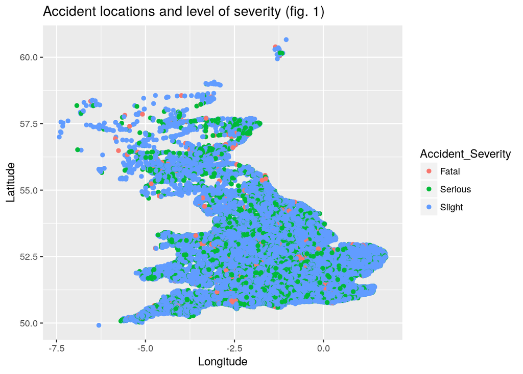

Now, our goal was to relate to each type of accident severity by month, and know, in this way, the distribution of accidents per month as we can see in *fig.2*.

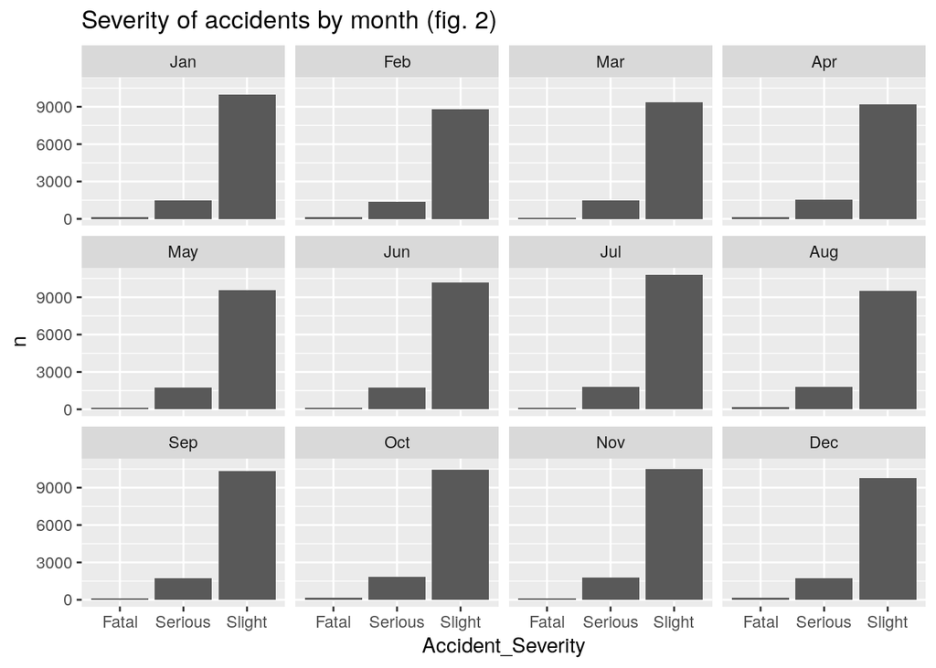

Now, our goal was to find out how the Accident Severity would behave when compared to the atmospheric conditions. From this data, we expect to see a higher frequency of Fatal accidents when put against bad weather conditions, as we can see on *fig.3*.

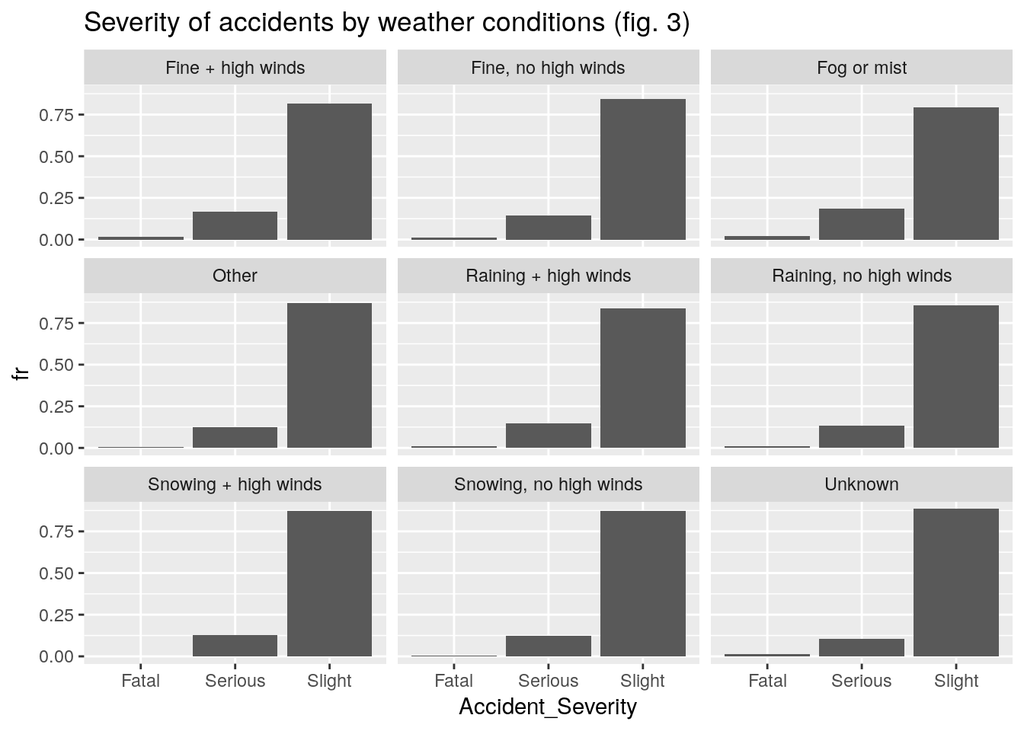

We also found interesting knowing the distribution of casualties. This graph could provide some perspective on the normal number of casualties per accident. So we generated the graph as you can see on *fig.4*.

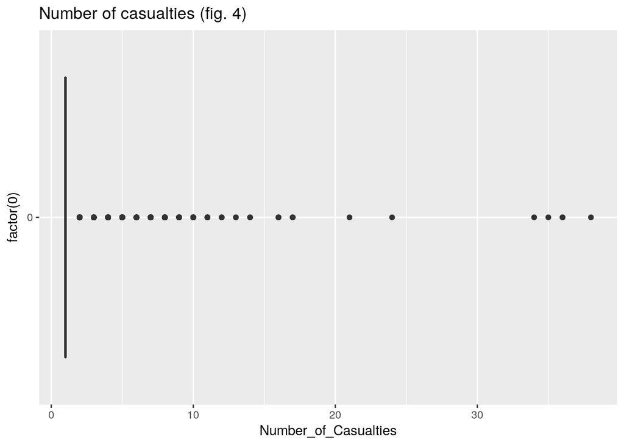

We also considered important to analyze the severity of accidents in comparison to the type of road, as you can observe on *fig.5*.

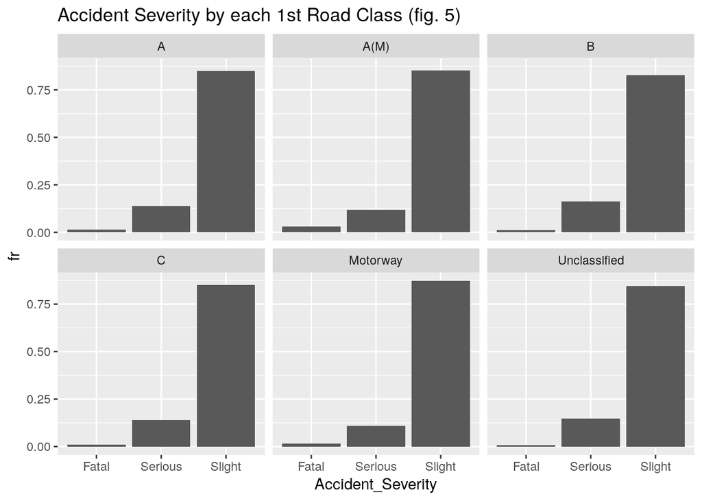

Finally, we found necessary to analyse casualty severity in relation to the first point of impact. For this it was necessary to have extra data, on this case was necessary to have a dataset relative to the vehicles and casualties. This data was also made available by the United Kingdom Government at https://data.gov.uk/dataset/road-accidents-safety-data

In this case, we expected to find some relation between the fatal accidents and a specific impact, so we created the graph in *fig.6*.

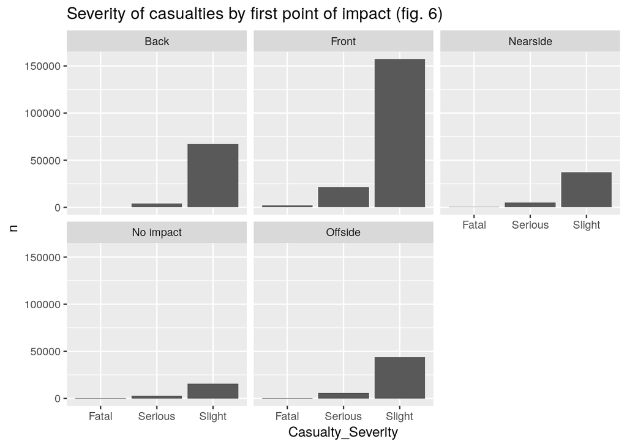

It is quite interesting to look at this data, because it could lead to some type of improvement by the manufacturers of the vehicles for critical sections like to strengthen the bodywork of that section of the car.

We can observe that all the higher percentage of impacts that result in a fatality are from Front impacts. For the rest of the points of impacts, it is fair to say that the most common type of casualty is Slight.

## Clustering

After exploring the data, we decided to select the attributes that we thought would give us the best association rules, but that task turned out to be impossible, since the dataset is so big that we found out that some attributes were good to find patterns in the conditions of the road, but not relevant to accidents where people are involved even eliminating some of columns that were not relevant to the pattern mining like the Longitude, Latitude, Police_Force, etc.

In a way, we wanted to create groups of attributes to execute the Apriori algorithm, so we decided to use DBSCAN clustering algorithm in order to create these groups. Before we executed the DBSCAN algorithm we decide to remove the duplicated values of the data set since it wouldn’t affect the result.

```r
data_apriori = data
data_apriori<-unique(data_apriori)
```

Recurring to a clustering algorithm would automate the selection of attributes to form groups and to discover and exclude the outlier points of the dataset. Since we decided to use DBSCAN algorithm, we needed to choose the minimal points (minPts) in the k-neighbourhood and the k-distance (eps). After some tries, we achieved a set of clusters that was reasonable with minPts=10 and eps=2:

```r
library(dbscan)
clusters <- dbscan(data_apriori, eps = 2, minPts = 10)
table(clusters$cluster)
```

```
##
##     0     1     2     3     4     5     6     7     8     9    10    11
## 37981  7397 26077  5616 15533   226  5091   834   773  1298   614  3695
##    12    13    14    15    16    17    18    19    20    21    22    23
##   204   426  1306   344   181  1593   667   219   114    88    83   199
##    24    25    26    27    28    29    30    31    32    33    34    35
##    34   149    20   520    81    21    11   283    37    72    14    14
##    36    37    38    39    40    41    42    43    44    45    46    47
##   658    32    80    54   159    10   570    75    51    11    86   216
##    48    49    50    51    52    53    54    55    56    57    58    59
##    17    16    21     9    10    43    19    40    74   685   510    44
##    60    61    62    63    64    65    66    67    68    69    70    71
##  2128   918  1719  7276   264  1103    12   274    94  2603    43   735
##    72    73    74    75    76    77    78    79    80    81    82    83
##    10    26    13    59    28    13   238    22    16    18    19    18
```

[output cut: 24 more lines]

With the clusters generated, we only needed to calculate the Apriori algorithm for each cluster. At the beginning, we didn’t want to generate all the possible rules since many of those rules wouldn’t be interesting, so we created a Top 20 rules with highest lift value for each cluster with support=0.6, confidence=0.8 and lift>1.2. This idea is based on the work done by Sachin Kumar and Durga Toshinwal in “A data mining framework to analyze road accident data”: https://journalofbigdata.springeropen.com/articles/10.1186/s40537-015-0035-y

```r
apply_apriori_clusters <- function(data_set, cluster_set){
  n_clusters <- c(1:max(unique(cluster_set$cluster)))
  subsets <- list()
  for(i in n_clusters){
    tt <- data_set[cluster_set$cluster==i,]
    tt[] <- lapply(tt, factor)
    ap_ <- apriori(tt, parameter=list(supp=0.6, conf=0.8, target="rules", minlen=2, maxlen=1000), control=list(verbose=FALSE))
    ap_ <- ap_[!is.redundant(ap_, measure="confidence"),]
    ss <- head(sort(ap_, decreasing=TRUE, na.last=NA, by="lift"), 20)
    ss <- subset(ss,lift>1.2)
    subsets[[i]] <- ss
  }
  subsets
}
subsets <- apply_apriori_clusters(data_apriori, clusters)
```

We produced some plots with the rules obtained for each cluster, under the conditions that we mentioned previously.

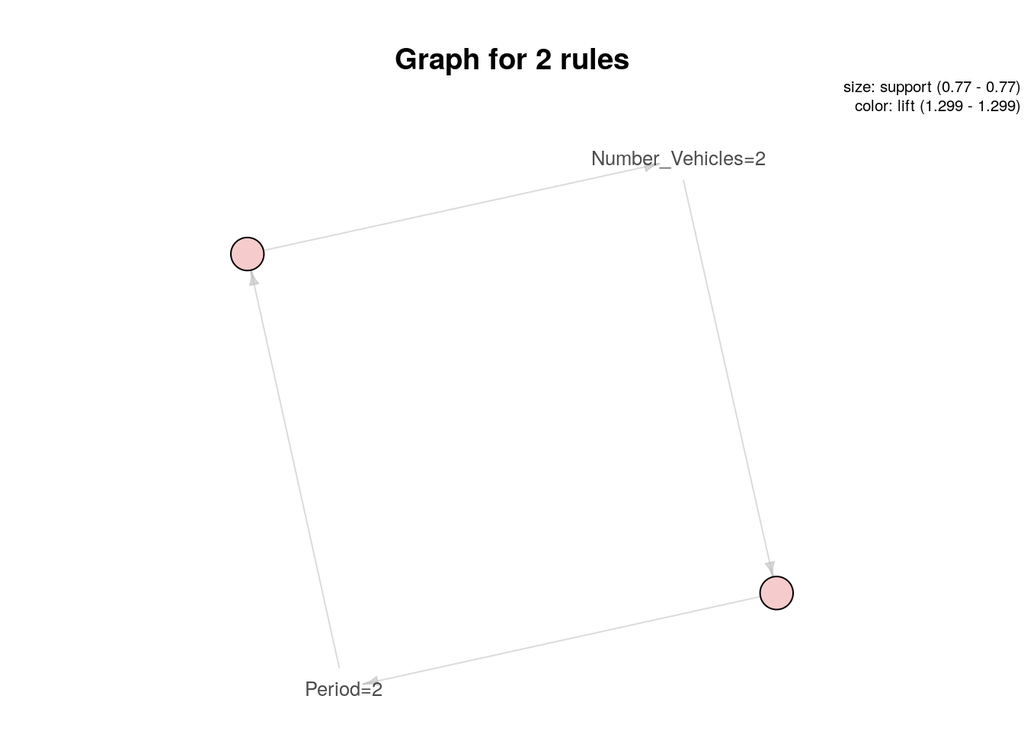

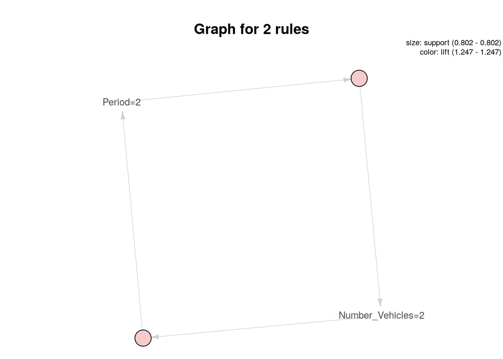

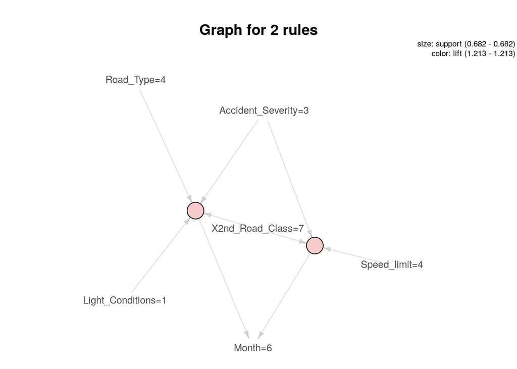

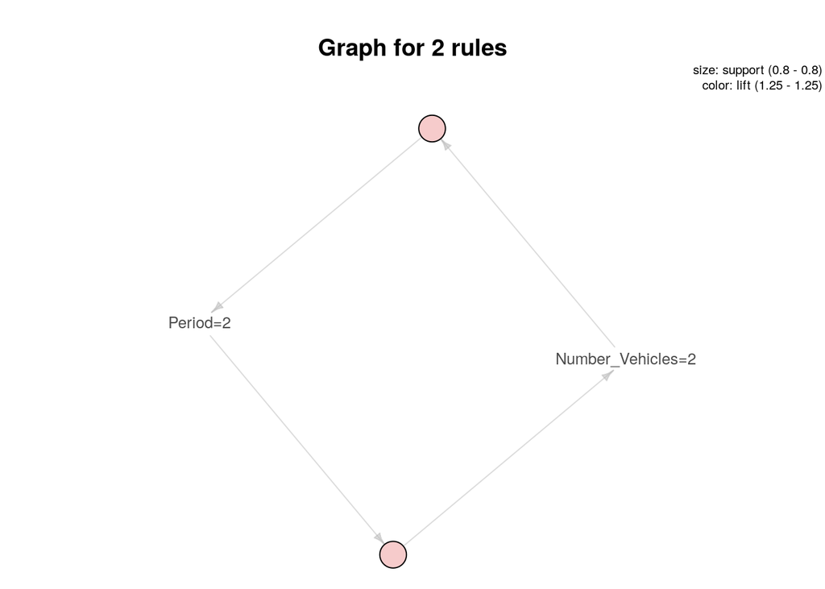

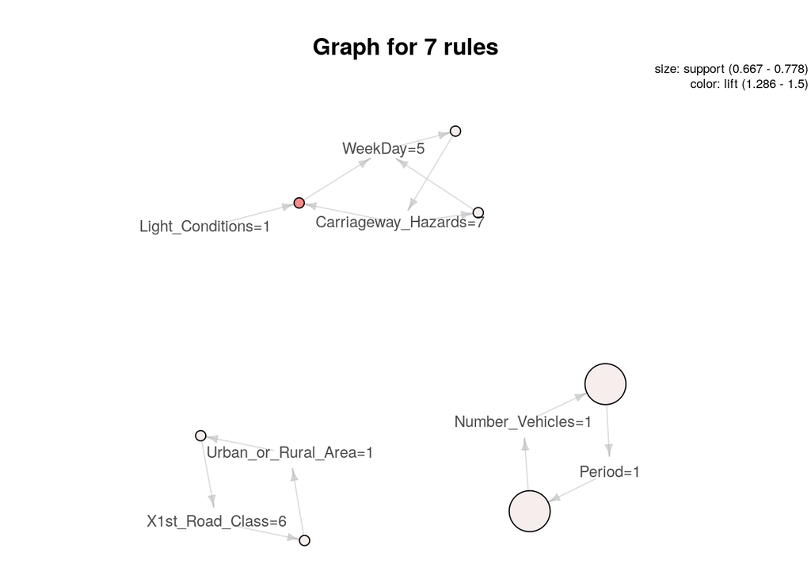

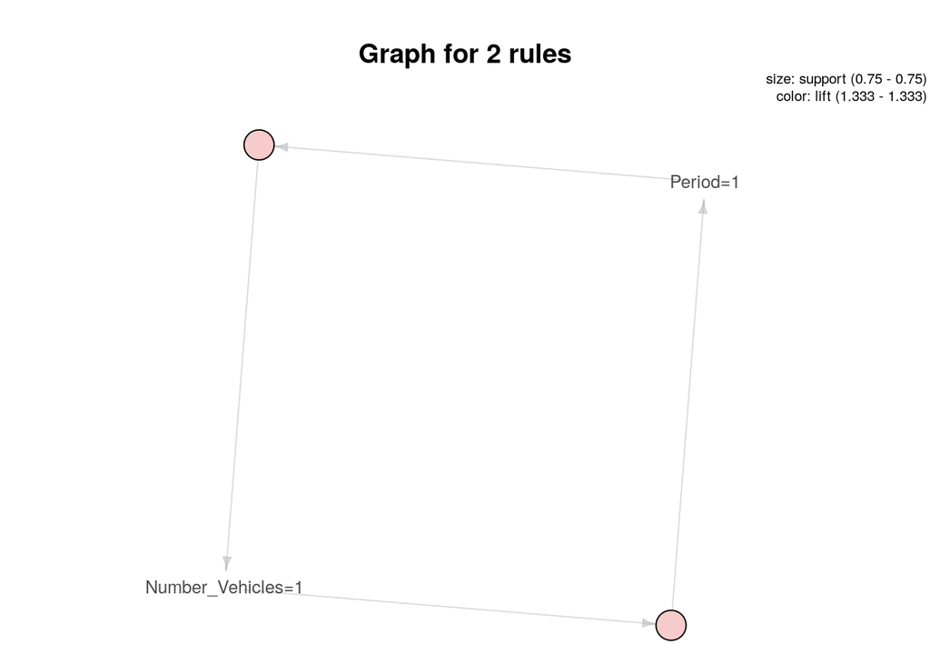

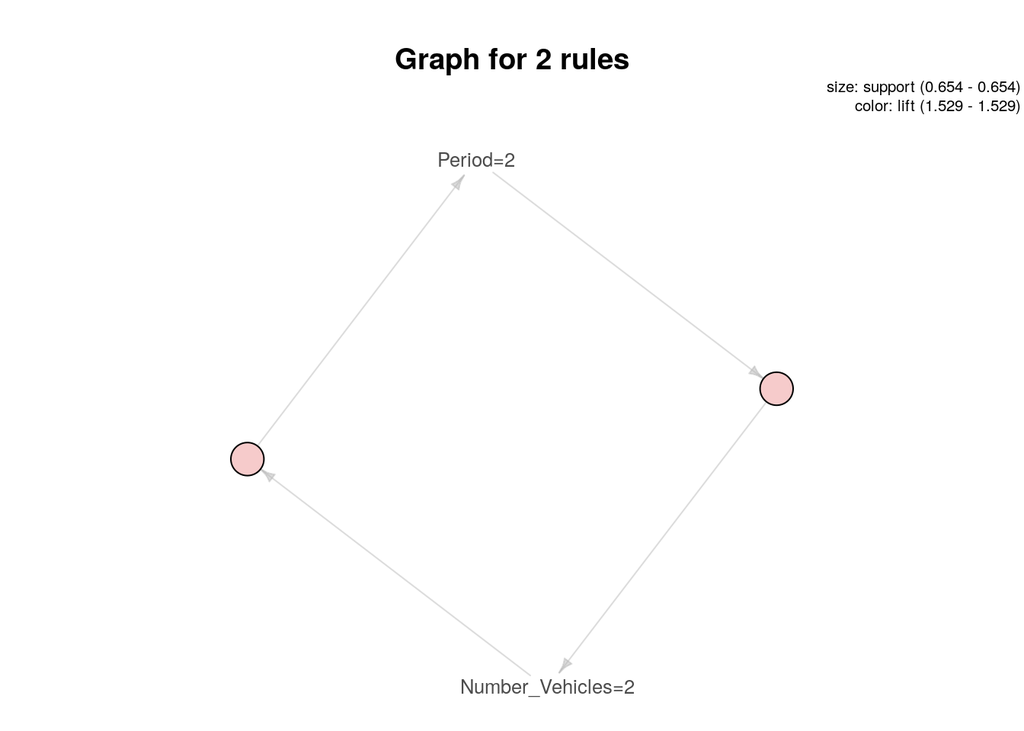

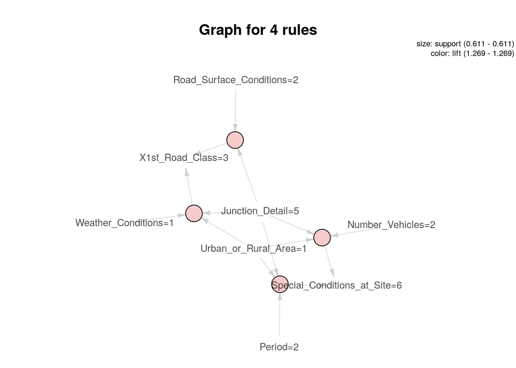

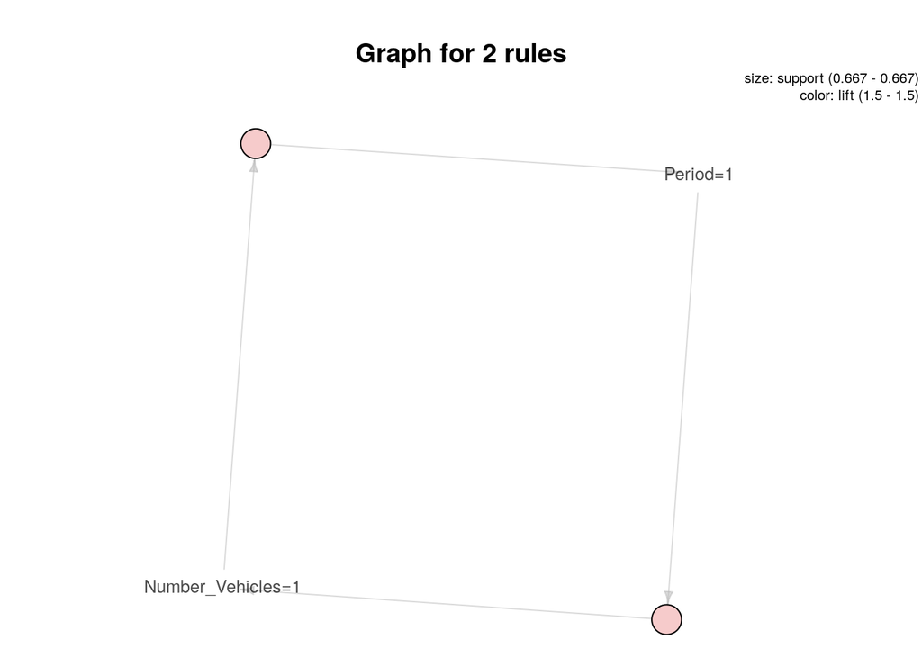

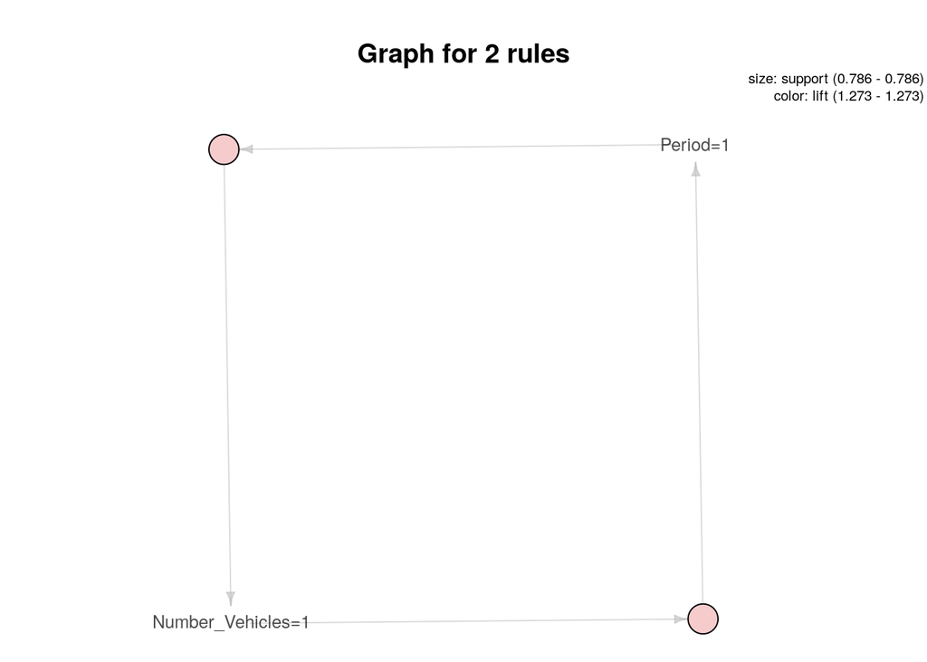

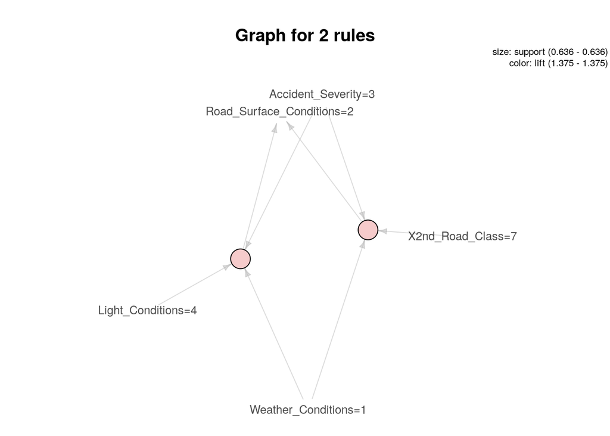

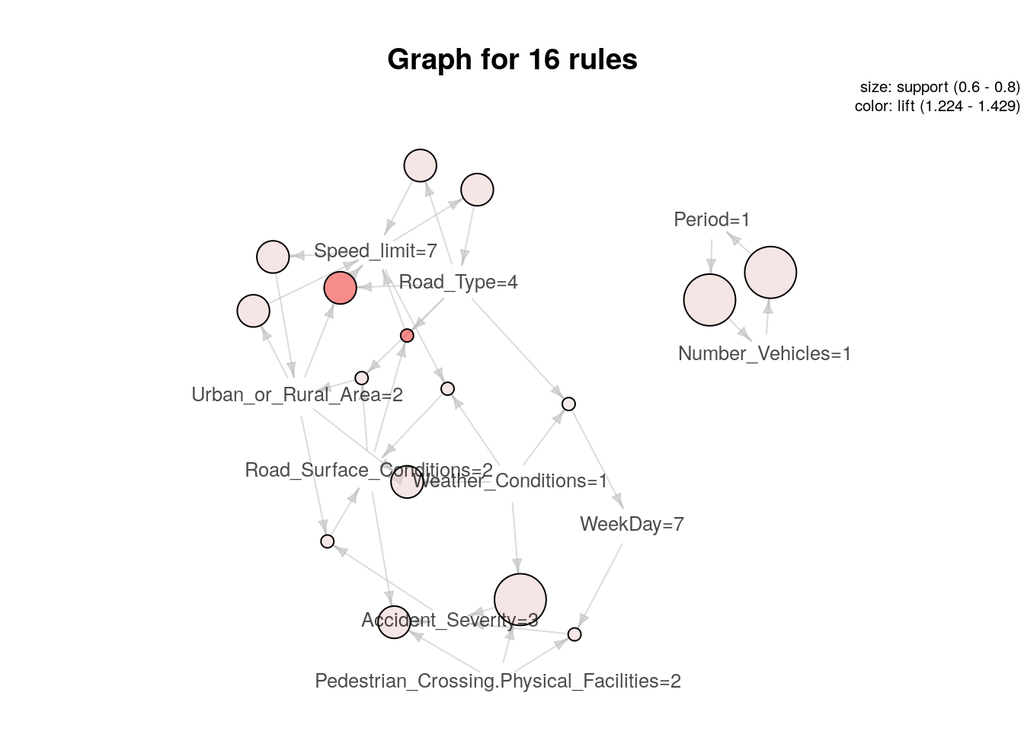

[8 more figures not shown]

```r
for (i in 1:length(subsets)) {
  if (length(subsets[[i]]) != 0)
    plot(subsets[[i]], method = "graph", control=list(cex=.8))
}
```

These are the 10 rules with highest lift value.

```
##      lhs                                            rhs                           support confidence     lift
## [1]  {Number_Vehicles=2,
##       Number_Casualties=1}                       => {Accident_Severity=3}       0.6250000  1.0000000 1.600000
## [2]  {Period=2,
##       Number_Casualties=1}                       => {Accident_Severity=3}       0.6250000  1.0000000 1.600000
## [3]  {Light_Conditions=1,
##       Carriageway_Hazards=7}                     => {WeekDay=5}                 0.6666667  1.0000000 1.500000
## [4]  {Road_Type=4,
##       Urban_or_Rural_Area=2}                     => {Speed_limit=7}             0.7000000  1.0000000 1.428571
## [5]  {Road_Type=4,
##       Road_Surface_Conditions=2}                 => {Speed_limit=7}             0.6000000  1.0000000 1.428571
## [6]  {Accident_Severity=3,
##       Pedestrian_Crossing.Physical_Facilities=2} => {X1st_Road_Class=3}         0.7000000  1.0000000 1.428571
## [7]  {Speed_limit=4,
##       Urban_or_Rural_Area=1,
##       Number_Casualties=1}                       => {WeekDay=6}                 0.6000000  0.8571429 1.428571
## [8]  {Speed_limit=7,
##       Urban_or_Rural_Area=2}                     => {Month=3}                   0.7142857  1.0000000 1.400000
## [9]  {Accident_Severity=3,
##       X2nd_Road_Class=7,
##       Weather_Conditions=1}                      => {Road_Surface_Conditions=2} 0.6363636  0.8750000 1.375000
## [10] {Accident_Severity=3,
##       Light_Conditions=4,
##       Weather_Conditions=1}                      => {Road_Surface_Conditions=2} 0.6363636  0.8750000 1.375000
```

After this procedure, we can conclude, from rules 1 and 2, that when the Number_Casualties is 1 (Individual) and either the Period is 2 (Morning) or the Number_Vehicles is 2 (Multiple), the Accident Severity is Slight. Although this seems normal, we were surprised to know that, if specific conditions occur, then it implies that the accident occurs at a specific week day or month as it shows in rules 3, 7 and 8.

What was not a surprise was the fact that not many rules had pedestrians involved, since in many of the roads present in the dataset, pedestrians are not allowed to walk. Also, since the UK is a very rainy country, the fact that the speed limit, road, weather and light conditions have correlations was not a surprise either.